# Market Basket Analysis

Duae Mariam

2023-02-25

### Introduction

Businesses (retailers) mostly use market basket analysis as a data mining tool to understand the preferences of their customers. Because of this, they are able to focus more on the needs of their customers, increasing profitability. This can show trends, such as the possibility that a customer who buys shoes in one store will also be interested in purchasing a jacket there.

### Loading the necessary libraries

```r
library(arules)
library(arulesViz)
library(kableExtra)
library(ggplot2)
```

### Loading the dataset(CSV format)

```r
data <- read.csv("Hotel Reservations.csv", stringsAsFactors = T)
```

Booking_ID

no_of_adults

no_of_children

no_of_weekend_nights

no_of_week_nights

type_of_meal_plan

required_car_parking_space

room_type_reserved

lead_time

arrival_year

arrival_month

arrival_date

market_segment_type

repeated_guest

no_of_previous_cancellations

no_of_previous_bookings_not_canceled

avg_price_per_room

no_of_special_requests

booking_status

### Basic Exploratory Data Analysis

#### Viewing some initial observations

```r
head(data)
```

```
##   Booking_ID no_of_adults no_of_children no_of_weekend_nights no_of_week_nights
## 1   INN00001            2              0                    1                 2
## 2   INN00002            2              0                    2                 3
## 3   INN00003            1              0                    2                 1
## 4   INN00004            2              0                    0                 2
## 5   INN00005            2              0                    1                 1
## 6   INN00006            2              0                    0                 2
##   type_of_meal_plan required_car_parking_space room_type_reserved lead_time
## 1       Meal Plan 1                          0        Room_Type 1       224
## 2      Not Selected                          0        Room_Type 1         5
## 3       Meal Plan 1                          0        Room_Type 1         1
## 4       Meal Plan 1                          0        Room_Type 1       211
## 5      Not Selected                          0        Room_Type 1        48
## 6       Meal Plan 2                          0        Room_Type 1       346
##   arrival_year arrival_month arrival_date market_segment_type repeated_guest
```

[output cut: 20 more lines]

#### Structure of the dataset

```r
str(data)
```

```
## 'data.frame':    891 obs. of  19 variables:
##  $ Booking_ID                          : Factor w/ 891 levels "INN00001","INN00002",..: 1 2 3 4 5 6 7 8 9 10 ...
##  $ no_of_adults                        : int  2 2 1 2 2 2 2 2 3 2 ...
##  $ no_of_children                      : int  0 0 0 0 0 0 0 0 0 0 ...
##  $ no_of_weekend_nights                : int  1 2 2 0 1 0 1 1 0 0 ...
##  $ no_of_week_nights                   : int  2 3 1 2 1 2 3 3 4 5 ...
##  $ type_of_meal_plan                   : Factor w/ 3 levels "Meal Plan 1",..: 1 3 1 1 3 2 1 1 1 1 ...
##  $ required_car_parking_space          : int  0 0 0 0 0 0 0 0 0 0 ...
##  $ room_type_reserved                  : Factor w/ 6 levels "Room_Type 1",..: 1 1 1 1 1 1 1 3 1 3 ...
##  $ lead_time                           : int  224 5 1 211 48 346 34 83 121 44 ...
##  $ arrival_year                        : int  2017 2018 2018 2018 2018 2018 2017 2018 2018 2018 ...
##  $ arrival_month                       : int  10 11 2 5 4 9 10 12 7 10 ...
##  $ arrival_date                        : int  2 6 28 20 11 13 15 26 6 18 ...
##  $ market_segment_type                 : Factor w/ 5 levels "Aviation","Complementary",..: 4 5 5 5 5 5 5 5 4 5 ...
##  $ repeated_guest                      : int  0 0 0 0 0 0 0 0 0 0 ...
##  $ no_of_previous_cancellations        : int  0 0 0 0 0 0 0 0 0 0 ...
##  $ no_of_previous_bookings_not_canceled: int  0 0 0 0 0 0 0 0 0 0 ...
##  $ avg_price_per_room                  : num  65 106.7 60 100 94.5 ...
##  $ no_of_special_requests              : int  0 1 0 0 0 1 1 1 1 3 ...
##  $ booking_status                      : Factor w/ 2 levels "Canceled","Not_Canceled": 2 2 1 1 1 1 2 2 2 2 ...
```

As it can be seen from the above statistics, some variables are probably not important for the further analysis, so there is a need for cleaning the dataset.

```r
summary(data)
```

```
##     Booking_ID   no_of_adults   no_of_children    no_of_weekend_nights
##  INN00001:  1   Min.   :0.000   Min.   :0.00000   Min.   :0.0000
##  INN00002:  1   1st Qu.:2.000   1st Qu.:0.00000   1st Qu.:0.0000
##  INN00003:  1   Median :2.000   Median :0.00000   Median :1.0000
##  INN00004:  1   Mean   :1.873   Mean   :0.09203   Mean   :0.8384
##  INN00005:  1   3rd Qu.:2.000   3rd Qu.:0.00000   3rd Qu.:2.0000
##  INN00006:  1   Max.   :4.000   Max.   :2.00000   Max.   :6.0000
##  (Other) :885
##  no_of_week_nights    type_of_meal_plan required_car_parking_space
##  Min.   : 0.000    Meal Plan 1 :667     Min.   :0.00000
##  1st Qu.: 1.000    Meal Plan 2 : 87     1st Qu.:0.00000
##  Median : 2.000    Not Selected:137     Median :0.00000
##  Mean   : 2.185                         Mean   :0.03816
##  3rd Qu.: 3.000                         3rd Qu.:0.00000
##  Max.   :15.000                         Max.   :1.00000
##
##    room_type_reserved   lead_time       arrival_year  arrival_month
##  Room_Type 1:681      Min.   :  0.00   Min.   :2017   Min.   : 1.000
##  Room_Type 2: 10      1st Qu.: 20.50   1st Qu.:2018   1st Qu.: 5.000
##  Room_Type 4:169      Median : 57.00   Median :2018   Median : 8.000
##  Room_Type 5:  4      Mean   : 83.68   Mean   :2018   Mean   : 7.264
##  Room_Type 6: 21      3rd Qu.:120.00   3rd Qu.:2018   3rd Qu.:10.000
##  Room_Type 7:  6      Max.   :443.00   Max.   :2018   Max.   :12.000
##
##   arrival_date      market_segment_type repeated_guest
##  Min.   : 1.00   Aviation     :  1      Min.   :0.00000
##  1st Qu.: 8.00   Complementary: 16      1st Qu.:0.00000
##  Median :15.00   Corporate    : 42      Median :0.00000
##  Mean   :15.25   Offline      :186      Mean   :0.02918
##  3rd Qu.:23.00   Online       :646      3rd Qu.:0.00000
##  Max.   :31.00                          Max.   :1.00000
##
##  no_of_previous_cancellations no_of_previous_bookings_not_canceled
##  Min.   :0.0000               Min.   : 0.000
##  1st Qu.:0.0000               1st Qu.: 0.000
##  Median :0.0000               Median : 0.000
##  Mean   :0.0202               Mean   : 0.119
##  3rd Qu.:0.0000               3rd Qu.: 0.000
##  Max.   :3.0000               Max.   :19.000
##
##  avg_price_per_room no_of_special_requests      booking_status
##  Min.   :  0.00     Min.   :0.0000         Canceled    :269
##  1st Qu.: 82.45     1st Qu.:0.0000         Not_Canceled:622
##  Median :101.50     Median :0.0000
##  Mean   :104.22     Mean   :0.6465
##  3rd Qu.:120.00     3rd Qu.:1.0000
##  Max.   :258.00     Max.   :4.0000
##
```

## Data Cleaning and Dimnesion Reduction

**Some of the techniques of Dimnesion Reduction used in the analysis below are:**

### Removing the NA values from the dataset

```r
sapply(data, function(x) sum(is.na(x)))
```

```
##                           Booking_ID                         no_of_adults
##                                    0                                    0
##                       no_of_children                 no_of_weekend_nights
##                                    0                                    0
##                    no_of_week_nights                    type_of_meal_plan
##                                    0                                    0
##           required_car_parking_space                   room_type_reserved
##                                    0                                    0
##                            lead_time                         arrival_year
##                                    0                                    0
##                        arrival_month                         arrival_date
##                                    0                                    0
##                  market_segment_type                       repeated_guest
##                                    0                                    0
##         no_of_previous_cancellations no_of_previous_bookings_not_canceled
##                                    0                                    0
##                   avg_price_per_room               no_of_special_requests
##                                    0                                    0
##                       booking_status
##                                    0
```

Here we see that there are no missing values

## Dimension reduction

```r
names(data)
```

```
##  [1] "Booking_ID"
##  [2] "no_of_adults"
##  [3] "no_of_children"
##  [4] "no_of_weekend_nights"
##  [5] "no_of_week_nights"
##  [6] "type_of_meal_plan"
##  [7] "required_car_parking_space"
##  [8] "room_type_reserved"
##  [9] "lead_time"
## [10] "arrival_year"
## [11] "arrival_month"
## [12] "arrival_date"
## [13] "market_segment_type"
## [14] "repeated_guest"
## [15] "no_of_previous_cancellations"
## [16] "no_of_previous_bookings_not_canceled"
## [17] "avg_price_per_room"
## [18] "no_of_special_requests"
## [19] "booking_status"
```

```r
data <- data[,c(-3,-9,-10,-12, -14 )]
```

### Scaling the variables for easier analysis

```r
data$avg_price_per_room <- data$avg_price_per_room/mean(data$avg_price_per_room)
```

### We need to factor some of the data columns for easier analysis

```r
col1 <- factor(data$booking_status, levels = c("Not_Canceled", "Canceled"), labels = c(0, 1))

data$booking_status <- col1
```

### Market Basket analysis of the Hotel reservation data using the apriori algorithm

#### Finding of several interesting association rules

```r
rules <- apriori(data,parameter = list(minlen = 2, conf = .8, supp = 0.14))
```

```
## Apriori
##
## Parameter specification:
##  confidence minval smax arem  aval originalSupport maxtime support minlen
##         0.8    0.1    1 none FALSE            TRUE       5    0.14      2
##  maxlen target  ext
##      10  rules TRUE
##
## Algorithmic control:
##  filter tree heap memopt load sort verbose
##     0.1 TRUE TRUE  FALSE TRUE    2    TRUE
##
## Absolute minimum support count: 124
##
## set item appearances ...[0 item(s)] done [0.00s].
## set transactions ...[925 item(s), 891 transaction(s)] done [0.01s].
## sorting and recoding items ... [25 item(s)] done [0.00s].
## creating transaction tree ... done [0.00s].
## checking subsets of size 1 2 3 4 5 6 7 8 done [0.01s].
## writing ... [9356 rule(s)] done [0.00s].
## creating S4 object  ... done [0.02s].
```

```r
inspect(head(sort(rules, by = "confidence", decreasing = T), 10))
```

```
##      lhs                                 rhs                                             support confidence  coverage     lift count
## [1]  {type_of_meal_plan=Not Selected} => {no_of_previous_bookings_not_canceled=[0,19]} 0.1537598          1 0.1537598 1.000000   137
## [2]  {type_of_meal_plan=Not Selected} => {no_of_previous_cancellations=[0,3]}          0.1537598          1 0.1537598 1.000000   137
## [3]  {type_of_meal_plan=Not Selected} => {required_car_parking_space=[0,1]}            0.1537598          1 0.1537598 1.000000   137
## [4]  {room_type_reserved=Room_Type 4} => {no_of_previous_bookings_not_canceled=[0,19]} 0.1896745          1 0.1896745 1.000000   169
## [5]  {room_type_reserved=Room_Type 4} => {no_of_previous_cancellations=[0,3]}          0.1896745          1 0.1896745 1.000000   169
## [6]  {room_type_reserved=Room_Type 4} => {required_car_parking_space=[0,1]}            0.1896745          1 0.1896745 1.000000   169
## [7]  {no_of_adults=[0,2)}             => {no_of_previous_bookings_not_canceled=[0,19]} 0.1907969          1 0.1907969 1.000000   170
## [8]  {no_of_adults=[0,2)}             => {no_of_previous_cancellations=[0,3]}          0.1907969          1 0.1907969 1.000000   170
## [9]  {no_of_adults=[0,2)}             => {required_car_parking_space=[0,1]}            0.1907969          1 0.1907969 1.000000   170
## [10] {market_segment_type=Offline}    => {booking_status=0}                            0.2087542          1 0.2087542 1.432476   186
```

The algorithm resuts in gathering all possible itemsets(rules), which the model observes in the data

#### Finding of specific interesting association rules

The following step tries to find those combinations:

```r
rules <- apriori(data,parameter = list(minlen = 2, conf = .8, supp = 0.14),
                 appearance=list(rhs=c("required_car_parking_space=[0,1]")))
```

```
## Apriori
##
## Parameter specification:
##  confidence minval smax arem  aval originalSupport maxtime support minlen
##         0.8    0.1    1 none FALSE            TRUE       5    0.14      2
##  maxlen target  ext
##      10  rules TRUE
##
## Algorithmic control:
##  filter tree heap memopt load sort verbose
##     0.1 TRUE TRUE  FALSE TRUE    2    TRUE
##
## Absolute minimum support count: 124
##
## set item appearances ...[1 item(s)] done [0.00s].
## set transactions ...[925 item(s), 891 transaction(s)] done [0.01s].
## sorting and recoding items ... [25 item(s)] done [0.00s].
## creating transaction tree ... done [0.00s].
## checking subsets of size 1 2 3 4 5 6 7 8 done [0.03s].
## writing ... [2263 rule(s)] done [0.00s].
## creating S4 object  ... done [0.00s].
```

```r
inspect(head(sort(rules, by = "confidence", decreasing = T), 5))
```

```
##     lhs                                 rhs                                  support confidence  coverage lift count
## [1] {type_of_meal_plan=Not Selected} => {required_car_parking_space=[0,1]} 0.1537598          1 0.1537598    1   137
## [2] {room_type_reserved=Room_Type 4} => {required_car_parking_space=[0,1]} 0.1896745          1 0.1896745    1   169
## [3] {no_of_adults=[0,2)}             => {required_car_parking_space=[0,1]} 0.1907969          1 0.1907969    1   170
## [4] {market_segment_type=Offline}    => {required_car_parking_space=[0,1]} 0.2087542          1 0.2087542    1   186
## [5] {arrival_month=[6,9)}            => {required_car_parking_space=[0,1]} 0.2760943          1 0.2760943    1   246
```

Moreover, the combinations do not make a lot of sense. Most of the guests in the hotel will either require a parking spot or not. But it is important to note that this dataset might not be the perfect one to use for such algorithm.

### Checking if there exist any redundancy in “rules”

```r
redundant <- is.redundant(rules, measure="confidence")
which(redundant)
```

```
##    [1]   25   26   27   28   29   30   31   32   33   34   35   36   37   38
##   [15]   39   40   41   42   43   44   45   46   47   48   49   50   51   52
##   [29]   53   54   55   56   57   58   59   60   61   62   63   64   65   66
##   [43]   67   68   69   70   71   72   73   74   75   76   77   78   79   80
##   [57]   81   82   83   84   85   86   87   88   89   90   91   92   93   94
##   [71]   95   96   97   98   99  100  101  102  103  104  105  106  107  108
##   [85]  109  110  111  112  113  114  115  116  117  118  119  120  121  122
##   [99]  123  124  125  126  127  128  129  130  131  132  133  134  135  136
##  [113]  137  138  139  140  141  142  143  144  145  146  147  148  149  150
##  [127]  151  152  153  154  155  156  157  158  159  160  161  162  163  164
##  [141]  165  166  167  168  169  170  171  172  173  174  175  176  177  178
##  [155]  179  180  181  182  183  184  185  186  187  188  189  190  191  192
##  [169]  193  194  195  196  197  198  199  200  201  202  203  204  205  206
##  [183]  207  208  209  210  211  212  213  214  215  216  217  218  219  220
##  [197]  221  222  223  224  225  226  227  228  229  230  231  232  233  234
```

[output cut: 145 more lines]

### Plot to show the above combination

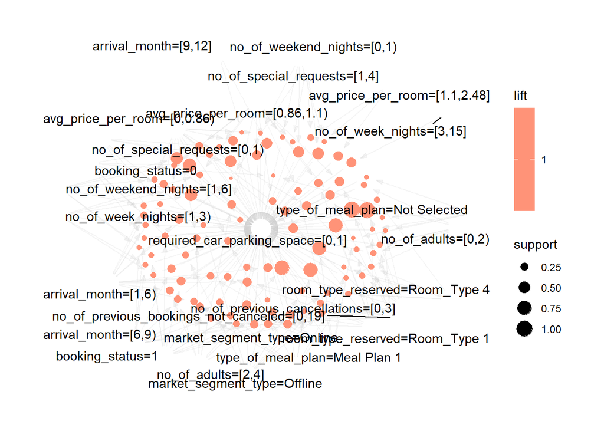

```r
plot(rules, method= "graph")
```

### References

1. https://searchcustomerexperience.techtarget.com/definition/market-basket-analysis
2. Association Rules and Market Basket Analysis with R, 8-4-2015, David Smith in R blogger
3. https://www.r-bloggers.com/2021/04/market-basket-analysis-in-r/
4. VENKATACHARI, K. and CHANDRASEKARAN, I.D., 2016. MARKET BASKET ANALYSIS USING FP GROWTH AND APRIORI ALGORITHM: A CASE STUDY OF MUMBAI RETAIL STORE. BVIMSR’s Journal of Management Research, 04, vol. 8, no. 1, pp. 56-63 ABI/INFORM Collection; ProQuest Central; Research Library.